# Project: Investigate a Dataset (TMDb Movie Data)

- Introduction
- Data Wrangling
- Exploratory Data Analysis
- Conclusions

## Introduction

### Dataset Description

#### Background

TMDB (The Movie Database) is a community built movie and TV database. It has a strong international focus with about 39 languages it officially supports. It also has an extensive regional data with daily usage of the database in over 180 countries. Therefore, this a great place to hit the ground running in analysis of the dataset from this database.

TMDb movie data set contains information about 5,000 movies collected from The Movie Database (TMDb), including user ratings and revenue. The column names in the table are as follows:

- budget
- genres
- homepage
- id
- keywords
- original_language
- original_title
- overview
- popularity
- production_companies
- production_countries
- release_date
- revenue
- runtime
- spoken_languages
- status
- tagline
- vote_average
- vote_count

### Question(s) for Analysis

1. Which genres are most popular from year to year?
2. What kind of properties are associated with movies that have high revenues?

```python
# importing statements for the needed packages

import pandas as pd
import numpy as np
import matplotlib.pyplot as plt
% matplotlib inline
import seaborn as sns
```

```python
# Upgrade pandas to use dataframe.explode() function.
#!pip install --upgrade pandas==0.25.0
```

## Data Wrangling

```python
# Loading data and printing out a few lines
pd.options.display.max_rows = 9999
df = pd.read_csv('tmdb_5000_movies.csv')
df.head(2)
```

|  | budget | genres | homepage | id | keywords | original_language | original_title | overview | popularity | production_companies | production_countries | release_date | revenue | runtime | spoken_languages | status | tagline | title | vote_average | vote_count |
| --- | --- | --- | --- | --- | --- | --- | --- | --- | --- | --- | --- | --- | --- | --- | --- | --- | --- | --- | --- | --- |
| 0 | 237000000 | [{"id": 28, "name": "Action"}, {"id": 12, "nam... | http://www.avatarmovie.com/ | 19995 | [{"id": 1463, "name": "culture clash"}, {"id":... | en | Avatar | In the 22nd century, a paraplegic Marine is di... | 150.437577 | [{"name": "Ingenious Film Partners", "id": 289... | [{"iso_3166_1": "US", "name": "United States o... | 2009-12-10 | 2787965087 | 162.0 | [{"iso_639_1": "en", "name": "English"}, {"iso... | Released | Enter the World of Pandora. | Avatar | 7.2 | 11800 |
| 1 | 300000000 | [{"id": 12, "name": "Adventure"}, {"id": 14, "... | http://disney.go.com/disneypictures/pirates/ | 285 | [{"id": 270, "name": "ocean"}, {"id": 726, "na... | en | Pirates of the Caribbean: At World's End | Captain Barbossa, long believed to be dead, ha... | 139.082615 | [{"name": "Walt Disney Pictures", "id": 2}, {"... | [{"iso_3166_1": "US", "name": "United States o... | 2007-05-19 | 961000000 | 169.0 | [{"iso_639_1": "en", "name": "English"}] | Released | At the end of the world, the adventure begins. | Pirates of the Caribbean: At World's End | 6.9 | 4500 |

Let's analyze the data to get more information on it and identify missing gaps

```python
#check dimensions of the table
df.shape
```

```
(4803, 20)
```

The dataset has 4803 total number of rows and 20 total number of columns

```python
#Check information about the dataframe

df.info()
```

```
<class 'pandas.core.frame.DataFrame'>
RangeIndex: 4803 entries, 0 to 4802
Data columns (total 20 columns):
budget                  4803 non-null int64
genres                  4803 non-null object
homepage                1712 non-null object
id                      4803 non-null int64
keywords                4803 non-null object
original_language       4803 non-null object
original_title          4803 non-null object
overview                4800 non-null object
popularity              4803 non-null float64
production_companies    4803 non-null object
production_countries    4803 non-null object
release_date            4802 non-null object
revenue                 4803 non-null int64
runtime                 4801 non-null float64
spoken_languages        4803 non-null object
status                  4803 non-null object
tagline                 3959 non-null object
title                   4803 non-null object
vote_average            4803 non-null float64
vote_count              4803 non-null int64
dtypes: float64(3), int64(4), object(13)
memory usage: 750.5+ KB
```

- We have 4803 number of row entries and 20 columns. There are 5 columns with null values: homepage, overview, release_date, runtime and tagline with the homepage column having a great significant number of missing values, more than half the number of available entries folowed by tagline. The rest have very few missing values.
- The release_date column is a string rather than datetime. We will later change this.

```python
#Check number of missing values in the dataset

df.isnull().sum()
```

```
budget                     0
genres                     0
homepage                3091
id                         0
keywords                   0
original_language          0
original_title             0
overview                   3
popularity                 0
production_companies       0
production_countries       0
release_date               1
revenue                    0
runtime                    2
spoken_languages           0
status                     0
tagline                  844
title                      0
vote_average               0
vote_count                 0
dtype: int64
```

We can observe that the homepage column has a total of 3091 missing entries out of the possible 4803 followed by tagline with 844. overview, release_date and runtime columns have very few rows of missing data.

```python
#Check for duplicates in the data

sum(df.duplicated())
```

```
0
```

There are no duplicates in the dataset

```python
#Check summary statistics of the dataset distribution

df.describe()
```

|  | budget | id | popularity | revenue | runtime | vote_average | vote_count |
| --- | --- | --- | --- | --- | --- | --- | --- |
| count | 4.803000e+03 | 4803.000000 | 4803.000000 | 4.803000e+03 | 4801.000000 | 4803.000000 | 4803.000000 |
| mean | 2.904504e+07 | 57165.484281 | 21.492301 | 8.226064e+07 | 106.875859 | 6.092172 | 690.217989 |
| std | 4.072239e+07 | 88694.614033 | 31.816650 | 1.628571e+08 | 22.611935 | 1.194612 | 1234.585891 |
| min | 0.000000e+00 | 5.000000 | 0.000000 | 0.000000e+00 | 0.000000 | 0.000000 | 0.000000 |
| 25% | 7.900000e+05 | 9014.500000 | 4.668070 | 0.000000e+00 | 94.000000 | 5.600000 | 54.000000 |
| 50% | 1.500000e+07 | 14629.000000 | 12.921594 | 1.917000e+07 | 103.000000 | 6.200000 | 235.000000 |
| 75% | 4.000000e+07 | 58610.500000 | 28.313505 | 9.291719e+07 | 118.000000 | 6.800000 | 737.000000 |
| max | 3.800000e+08 | 459488.000000 | 875.581305 | 2.787965e+09 | 338.000000 | 10.000000 | 13752.000000 |

- The above output prints the important summary statistics of the numerical variables in the data like mean, median (50%), minimum and maximum values, along with the standard deviation. We can also calculate the IQR using the 25th and 75the percentile values.
- In order to print the summary statistics for all the variables in the data, we need to add include='all' as below:

```python
df.describe(include = 'all')
```

|  | budget | genres | homepage | id | keywords | original_language | original_title | overview | popularity | production_companies | production_countries | release_date | revenue | runtime | spoken_languages | status | tagline | title | vote_average | vote_count |
| --- | --- | --- | --- | --- | --- | --- | --- | --- | --- | --- | --- | --- | --- | --- | --- | --- | --- | --- | --- | --- |
| count | 4.803000e+03 | 4803 | 1712 | 4803.000000 | 4803 | 4803 | 4803 | 4800 | 4803.000000 | 4803 | 4803 | 4802 | 4.803000e+03 | 4801.000000 | 4803 | 4803 | 3959 | 4803 | 4803.000000 | 4803.000000 |
| unique | NaN | 1175 | 1691 | NaN | 4222 | 37 | 4801 | 4800 | NaN | 3697 | 469 | 3280 | NaN | NaN | 544 | 3 | 3944 | 4800 | NaN | NaN |
| top | NaN | [{"id": 18, "name": "Drama"}] | http://www.missionimpossible.com/ | NaN | [] | en | Batman | Self-esteem and insecurity are at the heart of... | NaN | [] | [{"iso_3166_1": "US", "name": "United States o... | 2006-01-01 | NaN | NaN | [{"iso_639_1": "en", "name": "English"}] | Released | Based on a true story. | The Host | NaN | NaN |
| freq | NaN | 370 | 4 | NaN | 412 | 4505 | 2 | 1 | NaN | 351 | 2977 | 10 | NaN | NaN | 3171 | 4795 | 3 | 2 | NaN | NaN |
| mean | 2.904504e+07 | NaN | NaN | 57165.484281 | NaN | NaN | NaN | NaN | 21.492301 | NaN | NaN | NaN | 8.226064e+07 | 106.875859 | NaN | NaN | NaN | NaN | 6.092172 | 690.217989 |
| std | 4.072239e+07 | NaN | NaN | 88694.614033 | NaN | NaN | NaN | NaN | 31.816650 | NaN | NaN | NaN | 1.628571e+08 | 22.611935 | NaN | NaN | NaN | NaN | 1.194612 | 1234.585891 |
| min | 0.000000e+00 | NaN | NaN | 5.000000 | NaN | NaN | NaN | NaN | 0.000000 | NaN | NaN | NaN | 0.000000e+00 | 0.000000 | NaN | NaN | NaN | NaN | 0.000000 | 0.000000 |
| 25% | 7.900000e+05 | NaN | NaN | 9014.500000 | NaN | NaN | NaN | NaN | 4.668070 | NaN | NaN | NaN | 0.000000e+00 | 94.000000 | NaN | NaN | NaN | NaN | 5.600000 | 54.000000 |
| 50% | 1.500000e+07 | NaN | NaN | 14629.000000 | NaN | NaN | NaN | NaN | 12.921594 | NaN | NaN | NaN | 1.917000e+07 | 103.000000 | NaN | NaN | NaN | NaN | 6.200000 | 235.000000 |
| 75% | 4.000000e+07 | NaN | NaN | 58610.500000 | NaN | NaN | NaN | NaN | 28.313505 | NaN | NaN | NaN | 9.291719e+07 | 118.000000 | NaN | NaN | NaN | NaN | 6.800000 | 737.000000 |
| max | 3.800000e+08 | NaN | NaN | 459488.000000 | NaN | NaN | NaN | NaN | 875.581305 | NaN | NaN | NaN | 2.787965e+09 | 338.000000 | NaN | NaN | NaN | NaN | 10.000000 | 13752.000000 |

Now, we have the summary statistics for all the variables in the data. However, for the non-numeric variables, we don't have statistics such as mean or median but statisctics like frequency, top and unique labels.

### Data Cleaning

First, we won't be working with all the columns in the dataset so we can delete the columns we don't need especially homepage and tagline that we saw earlier have significant number of missing values.

```python
#dropping the unneeded columns

df.drop(['homepage', 'keywords','overview', 'tagline', 'vote_average', 'vote_count'], axis=1, inplace=True)

df.isnull().sum()
```

```
budget                  0
genres                  0
id                      0
original_language       0
original_title          0
popularity              0
production_companies    0
production_countries    0
release_date            1
revenue                 0
runtime                 2
spoken_languages        0
status                  0
title                   0
dtype: int64
```

```python
#dropping rows with missing values
df.dropna(axis=0, inplace=True)

df.info()
```

```
<class 'pandas.core.frame.DataFrame'>
Int64Index: 4800 entries, 0 to 4802
Data columns (total 14 columns):
budget                  4800 non-null int64
genres                  4800 non-null object
id                      4800 non-null int64
original_language       4800 non-null object
original_title          4800 non-null object
popularity              4800 non-null float64
production_companies    4800 non-null object
production_countries    4800 non-null object
release_date            4800 non-null object
revenue                 4800 non-null int64
runtime                 4800 non-null float64
spoken_languages        4800 non-null object
status                  4800 non-null object
title                   4800 non-null object
dtypes: float64(2), int64(3), object(9)
memory usage: 562.5+ KB
```

This has reduced the row entries to 4800 from 4803 and the columns to 14 from 20.

Let's now convert the release date column from string to date

```python
#Converting data type of release_date column

df['release_date'] = pd.to_datetime(df['release_date'], format= '%Y-%m-%d')
df.info()
```

```
<class 'pandas.core.frame.DataFrame'>
Int64Index: 4800 entries, 0 to 4802
Data columns (total 14 columns):
budget                  4800 non-null int64
genres                  4800 non-null object
id                      4800 non-null int64
original_language       4800 non-null object
original_title          4800 non-null object
popularity              4800 non-null float64
production_companies    4800 non-null object
production_countries    4800 non-null object
release_date            4800 non-null datetime64[ns]
revenue                 4800 non-null int64
runtime                 4800 non-null float64
spoken_languages        4800 non-null object
status                  4800 non-null object
title                   4800 non-null object
dtypes: datetime64[ns](1), float64(2), int64(3), object(8)
memory usage: 562.5+ KB
```

## Exploratory Data Analysis

### 1. Which genres are most popular from year to year?

For this question, we focus on the genres with high popularity. We are going to identify the genres with the highest number of movies in them and use it to produce the result.

```python
# Let's check the counts of unique values

df['genres'].value_counts().head(10)
```

```
[{"id": 18, "name": "Drama"}]                                                                    369
[{"id": 35, "name": "Comedy"}]                                                                   282
[{"id": 18, "name": "Drama"}, {"id": 10749, "name": "Romance"}]                                  164
[{"id": 35, "name": "Comedy"}, {"id": 10749, "name": "Romance"}]                                 144
[{"id": 35, "name": "Comedy"}, {"id": 18, "name": "Drama"}]                                      142
[{"id": 35, "name": "Comedy"}, {"id": 18, "name": "Drama"}, {"id": 10749, "name": "Romance"}]    109
[{"id": 27, "name": "Horror"}, {"id": 53, "name": "Thriller"}]                                    88
[{"id": 99, "name": "Documentary"}]                                                               67
[{"id": 27, "name": "Horror"}]                                                                    64
[{"id": 18, "name": "Drama"}, {"id": 53, "name": "Thriller"}]                                     62
Name: genres, dtype: int64
```

- We can observe that a single movie can belong to more than one genre. Most movies are in the Drama category followed by Comedy.
- For the movies with multiple genres, we can try to separate the genres to help us in answering our question.
- We can create a dummy of each of the genres and have a single column for each as below:

```python
genre_list = ['Drama','Comedy', 'Romance','Horror','Thriller','Fantasy','Documentary','Crime','Action','History','Animation','Family','Adventure','Music','Mystery','Science Fiction','Western','War', 'Foreign']
df_copy = pd.get_dummies(genre_list)
df_copy.head()
```

|  | Action | Adventure | Animation | Comedy | Crime | Documentary | Drama | Family | Fantasy | Foreign | History | Horror | Music | Mystery | Romance | Science Fiction | Thriller | War | Western |
| --- | --- | --- | --- | --- | --- | --- | --- | --- | --- | --- | --- | --- | --- | --- | --- | --- | --- | --- | --- |
| 0 | 0 | 0 | 0 | 0 | 0 | 0 | 1 | 0 | 0 | 0 | 0 | 0 | 0 | 0 | 0 | 0 | 0 | 0 | 0 |
| 1 | 0 | 0 | 0 | 1 | 0 | 0 | 0 | 0 | 0 | 0 | 0 | 0 | 0 | 0 | 0 | 0 | 0 | 0 | 0 |
| 2 | 0 | 0 | 0 | 0 | 0 | 0 | 0 | 0 | 0 | 0 | 0 | 0 | 0 | 0 | 1 | 0 | 0 | 0 | 0 |
| 3 | 0 | 0 | 0 | 0 | 0 | 0 | 0 | 0 | 0 | 0 | 0 | 1 | 0 | 0 | 0 | 0 | 0 | 0 | 0 |
| 4 | 0 | 0 | 0 | 0 | 0 | 0 | 0 | 0 | 0 | 0 | 0 | 0 | 0 | 0 | 0 | 0 | 1 | 0 | 0 |

We can now concatenate the genre dummies to the original dataframe.

```python
#Adding the dummy dataframe to the original one

new_df = pd.concat([df, df_copy], axis=1).drop(['genres'], axis=1)
new_df.head()
```

|  | budget | id | original_language | original_title | popularity | production_companies | production_countries | release_date | revenue | runtime | ... | Foreign | History | Horror | Music | Mystery | Romance | Science Fiction | Thriller | War | Western |
| --- | --- | --- | --- | --- | --- | --- | --- | --- | --- | --- | --- | --- | --- | --- | --- | --- | --- | --- | --- | --- | --- |
| 0 | 237000000 | 19995 | en | Avatar | 150.437577 | [{"name": "Ingenious Film Partners", "id": 289... | [{"iso_3166_1": "US", "name": "United States o... | 2009-12-10 | 2787965087 | 162.0 | ... | 0.0 | 0.0 | 0.0 | 0.0 | 0.0 | 0.0 | 0.0 | 0.0 | 0.0 | 0.0 |
| 1 | 300000000 | 285 | en | Pirates of the Caribbean: At World's End | 139.082615 | [{"name": "Walt Disney Pictures", "id": 2}, {"... | [{"iso_3166_1": "US", "name": "United States o... | 2007-05-19 | 961000000 | 169.0 | ... | 0.0 | 0.0 | 0.0 | 0.0 | 0.0 | 0.0 | 0.0 | 0.0 | 0.0 | 0.0 |
| 2 | 245000000 | 206647 | en | Spectre | 107.376788 | [{"name": "Columbia Pictures", "id": 5}, {"nam... | [{"iso_3166_1": "GB", "name": "United Kingdom"... | 2015-10-26 | 880674609 | 148.0 | ... | 0.0 | 0.0 | 0.0 | 0.0 | 0.0 | 1.0 | 0.0 | 0.0 | 0.0 | 0.0 |
| 3 | 250000000 | 49026 | en | The Dark Knight Rises | 112.312950 | [{"name": "Legendary Pictures", "id": 923}, {"... | [{"iso_3166_1": "US", "name": "United States o... | 2012-07-16 | 1084939099 | 165.0 | ... | 0.0 | 0.0 | 1.0 | 0.0 | 0.0 | 0.0 | 0.0 | 0.0 | 0.0 | 0.0 |
| 4 | 260000000 | 49529 | en | John Carter | 43.926995 | [{"name": "Walt Disney Pictures", "id": 2}] | [{"iso_3166_1": "US", "name": "United States o... | 2012-03-07 | 284139100 | 132.0 | ... | 0.0 | 0.0 | 0.0 | 0.0 | 0.0 | 0.0 | 0.0 | 1.0 | 0.0 | 0.0 |

5 rows × 32 columns

We now need to get the years from the release_date column in a separate column. This will allow us to compare popularity of the genres over the years. To accomplish this, we get the 4 digits representing the year

```python
#Extracting year from given date
new_df['release_year'] = pd.DatetimeIndex(new_df['release_date']).year
new_df['release_year'].head(10)
```

```
0    2009
1    2007
2    2015
3    2012
4    2012
5    2007
6    2010
7    2015
8    2009
9    2016
Name: release_year, dtype: int64
```

```python
count = new_df[['id', 'popularity', 'release_year']].groupby('release_year')
count.head()
```

|  | id | popularity | release_year |
| --- | --- | --- | --- |
| 0 | 19995 | 150.437577 | 2009 |
| 1 | 285 | 139.082615 | 2007 |
| 2 | 206647 | 107.376788 | 2015 |
| 3 | 49026 | 112.312950 | 2012 |
| 4 | 49529 | 43.926995 | 2012 |
| 5 | 559 | 115.699814 | 2007 |
| 6 | 38757 | 48.681969 | 2010 |
| 7 | 99861 | 134.279229 | 2015 |
| 8 | 767 | 98.885637 | 2009 |
| 9 | 209112 | 155.790452 | 2016 |
| 10 | 1452 | 57.925623 | 2006 |
| 11 | 10764 | 107.928811 | 2008 |
| 12 | 58 | 145.847379 | 2006 |
| 13 | 57201 | 49.046956 | 2013 |
| 14 | 49521 | 99.398009 | 2013 |
| 15 | 2454 | 53.978602 | 2008 |
| 16 | 24428 | 144.448633 | 2012 |
| 17 | 1865 | 135.413856 | 2011 |
| 18 | 41154 | 52.035179 | 2012 |
| 19 | 122917 | 120.965743 | 2014 |
| 20 | 1930 | 89.866276 | 2012 |
| 21 | 20662 | 37.668301 | 2010 |
| 22 | 57158 | 94.370564 | 2013 |
| 23 | 2268 | 42.990906 | 2007 |
| 24 | 254 | 61.226010 | 2005 |
| 25 | 597 | 100.025899 | 1997 |
| 26 | 271110 | 198.372395 | 2016 |
| 28 | 135397 | 418.708552 | 2015 |
| 30 | 558 | 35.149586 | 2004 |
| 31 | 68721 | 77.682080 | 2013 |

[output cut: 325 more lines]

```python
!pip install -U seaborn
```

A plot graph to compare trend of movies popularity over the years

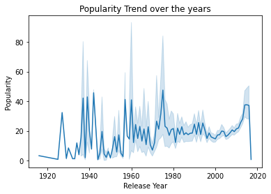

```python
ax = sns.lineplot(data = new_df, x='release_year', y='popularity')
ax.set_title('Popularity Trend over the years')
ax.set_xlabel('Release Year')
ax.set_ylabel('Popularity')
```

Let's focus on the genres of movies with high popularity. We can first identify top 10 genres with the most number of movies in them.

```python
#Getting the genre columns numbers
genres_col_index = new_df.iloc[:,13:-1]
print(genres_col_index.head())
print(genres_col_index.tail())
```

```
   Action  Adventure  Animation  Comedy  Crime  Documentary  Drama  Family  \
0     0.0        0.0        0.0     0.0    0.0          0.0    1.0     0.0
1     0.0        0.0        0.0     1.0    0.0          0.0    0.0     0.0
2     0.0        0.0        0.0     0.0    0.0          0.0    0.0     0.0
3     0.0        0.0        0.0     0.0    0.0          0.0    0.0     0.0
4     0.0        0.0        0.0     0.0    0.0          0.0    0.0     0.0

   Fantasy  Foreign  History  Horror  Music  Mystery  Romance  \
0      0.0      0.0      0.0     0.0    0.0      0.0      0.0
1      0.0      0.0      0.0     0.0    0.0      0.0      0.0
2      0.0      0.0      0.0     0.0    0.0      0.0      1.0
3      0.0      0.0      0.0     1.0    0.0      0.0      0.0
4      0.0      0.0      0.0     0.0    0.0      0.0      0.0

   Science Fiction  Thriller  War  Western
```

[output cut: 25 more lines]

We can observe a lot NaN values in the genres dataset. We can either delete those rows or fill them with zeros. For now, let's drop the rows with the Nan values.

```python
#Dropping rows with NaN values in the genre
genres_col_index.dropna(0)
```

|  | Action | Adventure | Animation | Comedy | Crime | Documentary | Drama | Family | Fantasy | Foreign | History | Horror | Music | Mystery | Romance | Science Fiction | Thriller | War | Western |
| --- | --- | --- | --- | --- | --- | --- | --- | --- | --- | --- | --- | --- | --- | --- | --- | --- | --- | --- | --- |
| 0 | 0.0 | 0.0 | 0.0 | 0.0 | 0.0 | 0.0 | 1.0 | 0.0 | 0.0 | 0.0 | 0.0 | 0.0 | 0.0 | 0.0 | 0.0 | 0.0 | 0.0 | 0.0 | 0.0 |
| 1 | 0.0 | 0.0 | 0.0 | 1.0 | 0.0 | 0.0 | 0.0 | 0.0 | 0.0 | 0.0 | 0.0 | 0.0 | 0.0 | 0.0 | 0.0 | 0.0 | 0.0 | 0.0 | 0.0 |
| 2 | 0.0 | 0.0 | 0.0 | 0.0 | 0.0 | 0.0 | 0.0 | 0.0 | 0.0 | 0.0 | 0.0 | 0.0 | 0.0 | 0.0 | 1.0 | 0.0 | 0.0 | 0.0 | 0.0 |
| 3 | 0.0 | 0.0 | 0.0 | 0.0 | 0.0 | 0.0 | 0.0 | 0.0 | 0.0 | 0.0 | 0.0 | 1.0 | 0.0 | 0.0 | 0.0 | 0.0 | 0.0 | 0.0 | 0.0 |
| 4 | 0.0 | 0.0 | 0.0 | 0.0 | 0.0 | 0.0 | 0.0 | 0.0 | 0.0 | 0.0 | 0.0 | 0.0 | 0.0 | 0.0 | 0.0 | 0.0 | 1.0 | 0.0 | 0.0 |
| 5 | 0.0 | 0.0 | 0.0 | 0.0 | 0.0 | 0.0 | 0.0 | 0.0 | 1.0 | 0.0 | 0.0 | 0.0 | 0.0 | 0.0 | 0.0 | 0.0 | 0.0 | 0.0 | 0.0 |
| 6 | 0.0 | 0.0 | 0.0 | 0.0 | 0.0 | 1.0 | 0.0 | 0.0 | 0.0 | 0.0 | 0.0 | 0.0 | 0.0 | 0.0 | 0.0 | 0.0 | 0.0 | 0.0 | 0.0 |
| 7 | 0.0 | 0.0 | 0.0 | 0.0 | 1.0 | 0.0 | 0.0 | 0.0 | 0.0 | 0.0 | 0.0 | 0.0 | 0.0 | 0.0 | 0.0 | 0.0 | 0.0 | 0.0 | 0.0 |
| 8 | 1.0 | 0.0 | 0.0 | 0.0 | 0.0 | 0.0 | 0.0 | 0.0 | 0.0 | 0.0 | 0.0 | 0.0 | 0.0 | 0.0 | 0.0 | 0.0 | 0.0 | 0.0 | 0.0 |
| 9 | 0.0 | 0.0 | 0.0 | 0.0 | 0.0 | 0.0 | 0.0 | 0.0 | 0.0 | 0.0 | 1.0 | 0.0 | 0.0 | 0.0 | 0.0 | 0.0 | 0.0 | 0.0 | 0.0 |
| 10 | 0.0 | 0.0 | 1.0 | 0.0 | 0.0 | 0.0 | 0.0 | 0.0 | 0.0 | 0.0 | 0.0 | 0.0 | 0.0 | 0.0 | 0.0 | 0.0 | 0.0 | 0.0 | 0.0 |
| 11 | 0.0 | 0.0 | 0.0 | 0.0 | 0.0 | 0.0 | 0.0 | 1.0 | 0.0 | 0.0 | 0.0 | 0.0 | 0.0 | 0.0 | 0.0 | 0.0 | 0.0 | 0.0 | 0.0 |
| 12 | 0.0 | 1.0 | 0.0 | 0.0 | 0.0 | 0.0 | 0.0 | 0.0 | 0.0 | 0.0 | 0.0 | 0.0 | 0.0 | 0.0 | 0.0 | 0.0 | 0.0 | 0.0 | 0.0 |
| 13 | 0.0 | 0.0 | 0.0 | 0.0 | 0.0 | 0.0 | 0.0 | 0.0 | 0.0 | 0.0 | 0.0 | 0.0 | 1.0 | 0.0 | 0.0 | 0.0 | 0.0 | 0.0 | 0.0 |
| 14 | 0.0 | 0.0 | 0.0 | 0.0 | 0.0 | 0.0 | 0.0 | 0.0 | 0.0 | 0.0 | 0.0 | 0.0 | 0.0 | 1.0 | 0.0 | 0.0 | 0.0 | 0.0 | 0.0 |
| 15 | 0.0 | 0.0 | 0.0 | 0.0 | 0.0 | 0.0 | 0.0 | 0.0 | 0.0 | 0.0 | 0.0 | 0.0 | 0.0 | 0.0 | 0.0 | 1.0 | 0.0 | 0.0 | 0.0 |
| 16 | 0.0 | 0.0 | 0.0 | 0.0 | 0.0 | 0.0 | 0.0 | 0.0 | 0.0 | 0.0 | 0.0 | 0.0 | 0.0 | 0.0 | 0.0 | 0.0 | 0.0 | 0.0 | 1.0 |
| 17 | 0.0 | 0.0 | 0.0 | 0.0 | 0.0 | 0.0 | 0.0 | 0.0 | 0.0 | 0.0 | 0.0 | 0.0 | 0.0 | 0.0 | 0.0 | 0.0 | 0.0 | 1.0 | 0.0 |
| 18 | 0.0 | 0.0 | 0.0 | 0.0 | 0.0 | 0.0 | 0.0 | 0.0 | 0.0 | 1.0 | 0.0 | 0.0 | 0.0 | 0.0 | 0.0 | 0.0 | 0.0 | 0.0 | 0.0 |

```python
top10_genres = genres_col_index.sum().sort_values(ascending=False).head(10).index.values
top10_genres
```

```
array(['Western', 'Fantasy', 'Adventure', 'Animation', 'Comedy', 'Crime',
       'Documentary', 'Drama', 'Family', 'Foreign'], dtype=object)
```

Now, let's find the most popular genres over the years. We will now include the release_year column.

```python
genres_pop = new_df.iloc[:,13:].groupby('release_year').sum().loc['2000':'2020', top10_genres]
genres_pop
```

| release_year | Western | Fantasy | Adventure | Animation | Comedy | Crime | Documentary | Drama | Family | Foreign |
| --- | --- | --- | --- | --- | --- | --- | --- | --- | --- | --- |
| 2000 | 0.0 | 0.0 | 0.0 | 0.0 | 0.0 | 0.0 | 0.0 | 0.0 | 0.0 | 0.0 |
| 2001 | 0.0 | 0.0 | 0.0 | 0.0 | 0.0 | 0.0 | 0.0 | 0.0 | 0.0 | 0.0 |
| 2002 | 0.0 | 0.0 | 0.0 | 0.0 | 0.0 | 0.0 | 0.0 | 0.0 | 0.0 | 0.0 |
| 2003 | 0.0 | 0.0 | 0.0 | 0.0 | 0.0 | 0.0 | 0.0 | 0.0 | 0.0 | 0.0 |
| 2004 | 0.0 | 0.0 | 0.0 | 0.0 | 0.0 | 0.0 | 0.0 | 0.0 | 0.0 | 0.0 |
| 2005 | 0.0 | 0.0 | 0.0 | 0.0 | 0.0 | 0.0 | 0.0 | 0.0 | 0.0 | 0.0 |
| 2006 | 0.0 | 0.0 | 1.0 | 1.0 | 0.0 | 0.0 | 0.0 | 0.0 | 0.0 | 0.0 |
| 2007 | 0.0 | 1.0 | 0.0 | 0.0 | 1.0 | 0.0 | 0.0 | 0.0 | 0.0 | 0.0 |
| 2008 | 0.0 | 0.0 | 0.0 | 0.0 | 0.0 | 0.0 | 0.0 | 0.0 | 1.0 | 0.0 |
| 2009 | 0.0 | 0.0 | 0.0 | 0.0 | 0.0 | 0.0 | 0.0 | 1.0 | 0.0 | 0.0 |
| 2010 | 0.0 | 0.0 | 0.0 | 0.0 | 0.0 | 0.0 | 1.0 | 0.0 | 0.0 | 0.0 |
| 2011 | 0.0 | 0.0 | 0.0 | 0.0 | 0.0 | 0.0 | 0.0 | 0.0 | 0.0 | 0.0 |
| 2012 | 1.0 | 0.0 | 0.0 | 0.0 | 0.0 | 0.0 | 0.0 | 0.0 | 0.0 | 1.0 |
| 2013 | 0.0 | 0.0 | 0.0 | 0.0 | 0.0 | 0.0 | 0.0 | 0.0 | 0.0 | 0.0 |
| 2014 | 0.0 | 0.0 | 0.0 | 0.0 | 0.0 | 0.0 | 0.0 | 0.0 | 0.0 | 0.0 |
| 2015 | 0.0 | 0.0 | 0.0 | 0.0 | 0.0 | 1.0 | 0.0 | 0.0 | 0.0 | 0.0 |
| 2016 | 0.0 | 0.0 | 0.0 | 0.0 | 0.0 | 0.0 | 0.0 | 0.0 | 0.0 | 0.0 |
| 2017 | 0.0 | 0.0 | 0.0 | 0.0 | 0.0 | 0.0 | 0.0 | 0.0 | 0.0 | 0.0 |

Let's create a graph to show most popular genres over the years with an average rolling of 2 years

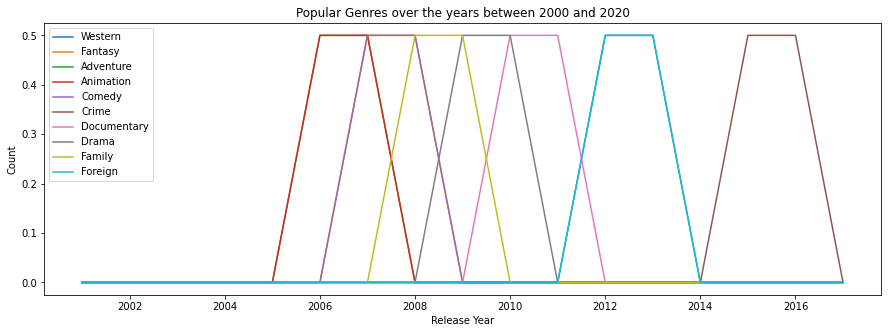

```python
ax = genres_pop.rolling(2).mean().plot(figsize = (15,5), title = 'Popular Genres over the years between 2000 and 2020')
ax.set_xlabel('Release Year')
ax.set_ylabel('Count')
```

### 2. What kind of properties are associated with movies that have high revenues?

Usually, high revenues in the movie industry is associated with movies that are highly popular or with high ratings. A brief google search of a case study looking at movie properties that lead to high revenues. Some of the properties that are in our dataset are: production_companies, released_date, runtime and genres.

```python
#Get high revenues generated from movies in the data
top_rev = df.nlargest(10, 'revenue')
top_rev
```

|  | budget | genres | id | original_language | original_title | popularity | production_companies | production_countries | release_date | revenue | runtime | spoken_languages | status | title |
| --- | --- | --- | --- | --- | --- | --- | --- | --- | --- | --- | --- | --- | --- | --- |
| 0 | 237000000 | [{"id": 28, "name": "Action"}, {"id": 12, "nam... | 19995 | en | Avatar | 150.437577 | [{"name": "Ingenious Film Partners", "id": 289... | [{"iso_3166_1": "US", "name": "United States o... | 2009-12-10 | 2787965087 | 162.0 | [{"iso_639_1": "en", "name": "English"}, {"iso... | Released | Avatar |
| 25 | 200000000 | [{"id": 18, "name": "Drama"}, {"id": 10749, "n... | 597 | en | Titanic | 100.025899 | [{"name": "Paramount Pictures", "id": 4}, {"na... | [{"iso_3166_1": "US", "name": "United States o... | 1997-11-18 | 1845034188 | 194.0 | [{"iso_639_1": "en", "name": "English"}, {"iso... | Released | Titanic |
| 16 | 220000000 | [{"id": 878, "name": "Science Fiction"}, {"id"... | 24428 | en | The Avengers | 144.448633 | [{"name": "Paramount Pictures", "id": 4}, {"na... | [{"iso_3166_1": "US", "name": "United States o... | 2012-04-25 | 1519557910 | 143.0 | [{"iso_639_1": "en", "name": "English"}] | Released | The Avengers |
| 28 | 150000000 | [{"id": 28, "name": "Action"}, {"id": 12, "nam... | 135397 | en | Jurassic World | 418.708552 | [{"name": "Universal Studios", "id": 13}, {"na... | [{"iso_3166_1": "US", "name": "United States o... | 2015-06-09 | 1513528810 | 124.0 | [{"iso_639_1": "en", "name": "English"}] | Released | Jurassic World |
| 44 | 190000000 | [{"id": 28, "name": "Action"}] | 168259 | en | Furious 7 | 102.322217 | [{"name": "Universal Pictures", "id": 33}, {"n... | [{"iso_3166_1": "JP", "name": "Japan"}, {"iso_... | 2015-04-01 | 1506249360 | 137.0 | [{"iso_639_1": "en", "name": "English"}] | Released | Furious 7 |
| 7 | 280000000 | [{"id": 28, "name": "Action"}, {"id": 12, "nam... | 99861 | en | Avengers: Age of Ultron | 134.279229 | [{"name": "Marvel Studios", "id": 420}, {"name... | [{"iso_3166_1": "US", "name": "United States o... | 2015-04-22 | 1405403694 | 141.0 | [{"iso_639_1": "en", "name": "English"}] | Released | Avengers: Age of Ultron |
| 124 | 150000000 | [{"id": 16, "name": "Animation"}, {"id": 12, "... | 109445 | en | Frozen | 165.125366 | [{"name": "Walt Disney Pictures", "id": 2}, {"... | [{"iso_3166_1": "US", "name": "United States o... | 2013-11-27 | 1274219009 | 102.0 | [{"iso_639_1": "en", "name": "English"}] | Released | Frozen |
| 31 | 200000000 | [{"id": 28, "name": "Action"}, {"id": 12, "nam... | 68721 | en | Iron Man 3 | 77.682080 | [{"name": "Marvel Studios", "id": 420}] | [{"iso_3166_1": "CN", "name": "China"}, {"iso_... | 2013-04-18 | 1215439994 | 130.0 | [{"iso_639_1": "en", "name": "English"}] | Released | Iron Man 3 |
| 546 | 74000000 | [{"id": 10751, "name": "Family"}, {"id": 16, "... | 211672 | en | Minions | 875.581305 | [{"name": "Universal Pictures", "id": 33}, {"n... | [{"iso_3166_1": "US", "name": "United States o... | 2015-06-17 | 1156730962 | 91.0 | [{"iso_639_1": "en", "name": "English"}] | Released | Minions |
| 26 | 250000000 | [{"id": 12, "name": "Adventure"}, {"id": 28, "... | 271110 | en | Captain America: Civil War | 198.372395 | [{"name": "Studio Babelsberg", "id": 264}, {"n... | [{"iso_3166_1": "US", "name": "United States o... | 2016-04-27 | 1153304495 | 147.0 | [{"iso_639_1": "ro", "name": "Rom\u00e2n\u0103... | Released | Captain America: Civil War |

We can observe that the top movie that generated the highest revenue is Avatar with over 2 billion dollars ($2,787,965,087 to be precise)

```python
#checking genre(s) of top revenue generating movie
top_rev.iloc[0,1]
```

```
'[{"id": 28, "name": "Action"}, {"id": 12, "name": "Adventure"}, {"id": 14, "name": "Fantasy"}, {"id": 878, "name": "Science Fiction"}]'
```

We can see that the top generating revenue movie, that is, Avatar belongs to more than one genre:Action, Adventure, Fantasy and Science Fiction.

```python
#Top producing companies
top_prod_com = df['production_companies'].value_counts()
top_prod_com.head()
```

```
[]                                            350
[{"name": "Paramount Pictures", "id": 4}]      58
[{"name": "Universal Pictures", "id": 33}]     45
[{"name": "New Line Cinema", "id": 12}]        38
[{"name": "Columbia Pictures", "id": 5}]       37
Name: production_companies, dtype: int64
```

Production companies producing most movies are Paramount Pictures, Universal Pictures, New Line Cinema and Columbia Pictures. The first 2 production companies also feature in our top 10 highest revenues generated from movies.

Let's look at the relationship or impact that a budget has in generating revenues from the movie produced.

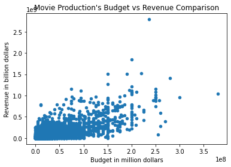

```python
ax = new_df.plot(x='budget', y= 'revenue', kind = 'scatter', title='Movie Production\'s Budget vs Revenue Comparison');
ax.set_xlabel('Budget in million dollars')
ax.set_ylabel('Revenue in billion dollars')
```

Let's also calculate the Pearson's Correlation Coefficient between budget and revenue relationship

```python
def correlation_coeff(x,y):
    std_x=(x-x.mean())/x.std(ddof=0)
    std_y=(y-y.mean())/y.std(ddof=0)
    return(std_x*std_y).mean()

correlation_coeff(new_df['budget'],new_df['revenue'])
```

```
0.730781210049316
```

The coeefificient returns a value of 0.73 which indicates there is a notable correlation between budget and revenue in movie production. Correlation coefficient 0.73 is a fairly strong positive relationship thus budget allocation and generation of revenue go in the same direction.

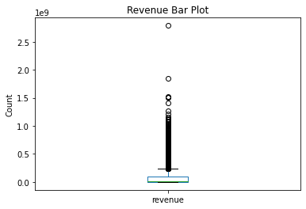

```python
ax = new_df['revenue'].plot(kind = 'box',title='Revenue Bar Plot');
ax.set_ylabel('Count')
```

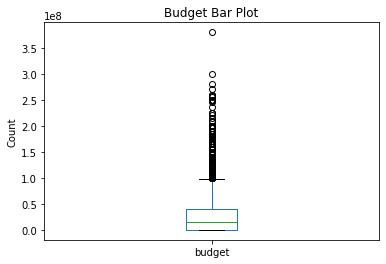

```python
ax = new_df['budget'].plot(kind = 'box', title='Budget Bar Plot');
ax.set_ylabel('Count')
```

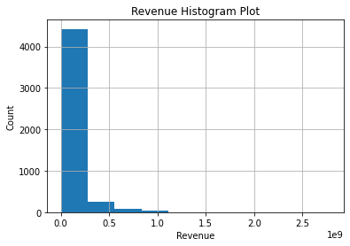

```python
ax = new_df['revenue'].hist();
ax.set_title('Revenue Histogram Plot')
ax.set_xlabel('Revenue')
ax.set_ylabel('Count')
```

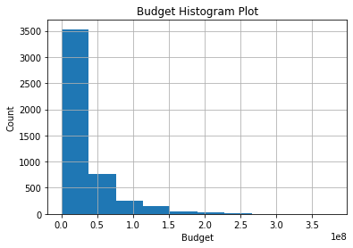

```python
ax = new_df['budget'].hist();
ax.set_title('Budget Histogram Plot')
ax.set_xlabel('Budget')
ax.set_ylabel('Count')
```

```python
new_df.budget.describe()
```

```
count    4.800000e+03
mean     2.906007e+07
std      4.073029e+07
min      0.000000e+00
25%      8.000000e+05
50%      1.500000e+07
75%      4.000000e+07
max      3.800000e+08
Name: budget, dtype: float64
```

```python
new_df.revenue.describe()
```

```
count    4.800000e+03
mean     8.231205e+07
std      1.628950e+08
min      0.000000e+00
25%      0.000000e+00
50%      1.918199e+07
75%      9.293886e+07
max      2.787965e+09
Name: revenue, dtype: float64
```

## Conclusions

#### Limitation

- More movies had multiple genres and in separating the genres, many rows were lost that contained NaN vlaues.
- Getting a visual to establish association of production companies and revenue.

### References

- https://stackoverflow.com
- https://codingnomads.co/blog/data-analysis-example-analyzing-movie-ratings-with-python/
- https://www.pluralsight.com/guides/interpreting-data-using-descriptive-statistics-python

```python
from subprocess import call
call(['python', '-m', 'nbconvert', 'Investigate_a_Dataset.ipynb'])
```